# Lab-13: Web Technologies

Stat 133

Author

Drew Nguyen, and Gaston Sanchez

# 1 Introduction

In this lab, we’ll try to scrape data from the web. The lab is purposely somewhat unstructured.

First, try to answer this question in your own words:

**What is an API? Please give two examples.**

…replace this sentence with your solution…

We will use the BART Legacy API, from class, to get some practice using an API to get, and maybe plot, some interesting data.

# 2 Understanding BART Legacy API

If you haven’t already, look at the following two links for information on the BART API.

Link 1: A basic about page for the API  
https://www.bart.gov/schedules/developers/api

Link 2: The documentation for the API  
https://api.bart.gov/docs/overview/index.aspx

APIs often have documentation you are forced to navigate, which can be slightly different for each API.

## 2.1 Your Turn: List of Bart Stations

Suppose you need to figure out how to use the BART Legacy API to find a **list of all BART stations**. To learn how to get it, you need to read the documentation about how to get “list of all BART stations”.

Try to browse Link 2 and find the URL to the documentation *yourself*, before checking the answer.

(Have you found it? [The documentation is here](https://api.bart.gov/docs/stn/stns.aspx).)

In the next question, address each section of the documentation separately. There are three main ones, Inputs, Results, and Usage, of which Usage is the most important.

**Please describe what each section of the documentation is about.**

…replace this sentence with your solution…

# 3 Getting access to the API

In APIs, usually some kind of **key** is required in order to get access to the service. Usually you are required to register for your own, personal key, but the BART API has a key anyone can use.

**For the BART API, find the key. What is it?**

…replace this sentence with your solution…

**Why do APIs require keys such as this?**

…replace this sentence with your solution…

# 4 Example: Downloading a list of all Bart stations

We’ll give you code that can be used to generate a table of all BART stations, containing columns for their `name`, `abbr` (abbreviation), `city`, `address`, `longitude` and `latitude`

**Important Note**. As provided, the code doesn’t work; the key is purposely omitted. Please reinsert it to get the code to work.

```r
# Assemble the URL with query fields
# Please update "key" with correct value!!!
base_url = "https://api.bart.gov/api/stn.aspx?"
cmd = "cmd=stns"
key = "key=INSERT-KEY-HERE"
json = "json=y"
query = paste(cmd, key, json, sep = '&')
stn_url = paste0(base_url, query)
```

```r
# Import JSON data
bart_stations = read_json(stn_url)

# Get number of stations
stn_lst = bart_stations$root$stations$station

# Reshape stations information into data table
stations_table = bind_rows(stn_lst)

stations_dat = stations_table |>
  select(name, abbr, city, address, gtfs_longitude, gtfs_latitude) |>
  mutate(longitude = as.numeric(gtfs_longitude),
         latitude = as.numeric(gtfs_latitude))
```

**What kind of object is `stn_lst`?**

…replace this sentence with your solution…

## 4.1 Mapping Bart stations

The following code lets you create a leaflet map to display the location of BART stations. As you can tell, the chunk needs to be *activated* by switching its option to `eval = TRUE`

```r
# evaluate this chunk!!!
stations_dat |>
leaflet() |>
  addProviderTiles(provider = "CartoDB.Positron") |>
  addCircles(lng = ~longitude,
             lat = ~latitude,
             label = ~name)
```

[interactive chart not shown]

# 5 BART Fares

The tutorial is over. Now, let’s get data about the **fares** for going from Downtown Berkeley to all other stations.

Look at the API’s documentation on **Schedule Information**:  
https://api.bart.gov/docs/sched/index.aspx

Specifically, read how to use the API command to request the fare for a trip between two stations:  
https://api.bart.gov/docs/sched/fare.aspx

## 5.1 Sample Query URL

The following chunk is one suggestion to assemble the string for the URL to request the fare between two stations. As you can tell, there are various (incomplete) commands with `...`. You’ll have to replace them with correct values to get a sample URL.

```r
# Assemble the URL with query fields
sched_url = "https://api.bart.gov/api/sched.aspx?"

# Please update all  "..."  with appropriate values!!!
cmd = "cmd=..."
orig = "orig=..."
dest = "dest=..."
date = "date=..."
key = "key=..."
json = "json=y"

query = paste(cmd, orig, dest, date, key, json, sep = '&')

fare_url = paste0(sched_url, query)
```

## 5.2 Your Turn: Fares from DBRK to other stations

Using the information at your disposal, the goal is to make a data frame that contains:

1. the `name`, `abbr` (abbreviation), `longitude`, and `latitude` of each station, and
2. the standard `fare` for going from Downtown Berkeley to that station. (You get an error if you try to get the fare from DBRK to DBRK, so just set it to zero.)

This means that you will have to write a loop to get the fare between DBRK and all other stations.

**Be sure to print every row so we can see it.**

```r
# Your code here...
```

For confirmation purposes (to make sure you have the right values), the correct abbreviation and fare from DBRK values are included below (fares as of April 2024):

| abbr | fare_from_DBRK |
| --- | --- |
| 12TH | 2.30 |
| 16TH | 4.85 |
| 19TH | 2.30 |
| 24TH | 4.90 |
| ANTC | 6.55 |
| ASHB | 2.30 |
| BALB | 5.20 |
| BAYF | 3.90 |
| BERY | 7.20 |
| CAST | 4.25 |
| CIVC | 4.75 |
| COLS | 3.05 |
| COLM | 5.30 |
| CONC | 4.75 |
| DALY | 5.30 |
| DBRK | 0 |
| DUBL | 5.55 |
| DELN | 2.30 |
| PLZA | 2.30 |
| EMBR | 4.75 |
| FRMT | 5.55 |
| FTVL | 2.70 |
| GLEN | 5.10 |
| HAYW | 4.25 |
| LAFY | 3.65 |
| LAKE | 2.30 |
| MCAR | 2.30 |
| MLBR | 6.20 |
| MLPT | 6.90 |
| MONT | 4.75 |
| NBRK | 2.30 |
| NCON | 5.00 |
| OAKL | 10.15 |
| ORIN | 2.90 |
| PITT | 5.60 |
| PCTR | 5.80 |
| PHIL | 4.30 |
| POWL | 4.75 |
| RICH | 2.30 |
| ROCK | 2.30 |
| SBRN | 5.80 |
| SFIA | 11.25 |
| SANL | 3.60 |
| SHAY | 4.60 |
| SSAN | 5.50 |
| UCTY | 5.15 |
| WCRK | 4.10 |
| WARM | 6.05 |
| WDUB | 5.35 |
| WOAK | 2.35 |

## 5.3 Your Turn: Map of Fares

It would be nice if you could plot a map to display the location of each BART station, color coding them based on the fares from Downtown Berkeley (`DBRK`).

Your map could look something like the image below (btw: the circles are colored using the `"viridis"` palette in reverse order).

*Hint*: To get a nice color palette to color-code the circles in leaflet, take a look at the following link: https://rstudio.github.io/leaflet/articles/colors.html

```r
# ... your code here
```

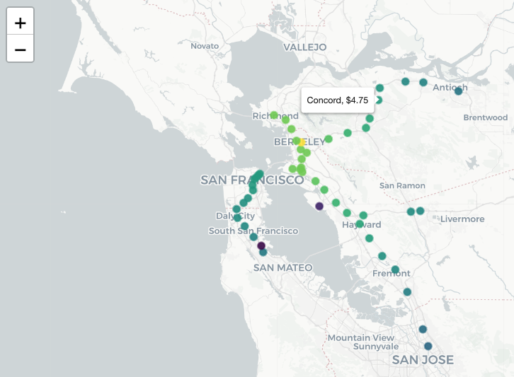